# IDA Assignment 2

Johnny Lee, s1687781

25th March 2022

# Q1.

Suppose $Y_1, \cdots , Y_n$ are independent and identically distributed with cumulative distribution function given by
$$F(y;\theta) = 1 - e^{-y^2/(2\theta)}, \quad y \geq 0, \quad \theta > 0.$$
Further suppose that observations are (right) censored if $Y_i > C$, for some known $C > 0$, and let
$$\begin{equation*}
X_i=
\begin{cases}
Y_i \quad \text{if} \quad Y_i \leq C,\\
C \quad \text{if} \quad Y_i > C,
\end{cases}
\quad
R_i=
\begin{cases}
1 \quad \text{if} \quad Y_i \leq C\\
0 \quad \text{if} \quad Y_i > C
\end{cases}
\end{equation*}$$

## a)

Show that the maximum likelihood estimator based on the observed data $\{(x_i,r_i)\}^{n}_{i=1}$ is given by
$$\hat{\theta} = \frac{\sum_{i=1}^n X_i^2}{2\sum_{i=1}^nR_i}.$$

### **Answer** :

We first define the Survival function (from **Workshop 3**)as
$$S(C;\theta)=\mathbb{P}(Y_i>C;\theta)=1-F(y_i;\theta)$$
which also represents the censored observations. For the uncensored observations, we have
$$f(y_i;\theta)=\frac{d}{dy_i}F(y_i;\theta)=\frac{ye^{-y^2/2\theta}}{\theta}$$
Given that $Y_1,\dots,Y_n$ are independent and identically distributed, we have the likelihood function as,
$$\begin{equation}\label{eq:likelihood}
\begin{split}
L(\theta|\boldsymbol{y,r})&= \prod^{n}_{i=1} \bigg( [f(y_i;\theta)]^{r_i} [S(C;\theta)]^{1-r_i}\bigg)\\
&= \prod^{n}_{i=1} \bigg( [\frac{y_i e^{-y_i^2/2\theta}}{\theta}]^{r_i} [e^{-C^2/\theta}]^{1-r_i}\bigg)\\
&= \bigg(\prod^{n}_{i=1}y_i^{r_i}\bigg)\bigg(\frac{1}{\theta}\bigg)^{\sum^{n}_{i=1}r_i}\exp\bigg(\frac{\sum^{n}_{i=1}(r_i y^2_i +(1-r_i)C^2)}{2\theta}\bigg)
\end{split}
\end{equation}$$

Now we can rewrite the expression inside the exponential in terms of $X_i$. $X_i$ can be expressed as
$$x_i=r_iy_i+C(1-r_i)$$
Then by taking square on both sides we have,
$$x_i^2=r_i^2y_i^2+(1-r_i)^2C^2+2r_iy_iC(1-r_i)$$
Noting that $R_i$ is binary, we can then conclude with the expression as
$$\begin{equation} \label{eq:x}
\begin{split}
x_i^2=r_iy_i^2+(1-r_i)C^2
\end{split}
\end{equation}$$

## b)

Show that the expected Fisher Information for the observed data likelihood is
$$I(\theta) = \frac{n}{\theta^2}(1 - e^{-C^2/(2\theta)})$$

**Note:** $\int_0^Cy^2f(y;\theta)dy = -C^2e^{-C^2/(2\theta)} + 2\theta(1 - e^{-C^2 / (2\theta)})$, where $f(y;\theta)$ is the density function corresponding to the cumulative distribution function $F(y;\theta)$ defined above.

### **Answer** :

Again, noting that $R_i$ is binary,
$$\begin{equation}\label{eq:expR}
\begin{split}
\mathbb{E}(R)&=1\cdot\mathbb{P}(R=1)+0\cdot\mathbb{P}(R=0)\\
&=\mathbb{P}(R=1)=\mathbb{P}(Y\leq C)\\
&=F(C;\theta) = 1-e^{-C^2/2\theta} \\
\implies \mathbb{E}(1-R)&=e^{-C^2/2\theta}
\end{split}
\end{equation}$$

With the given equation, $\mathbb{E}(RY^2)=\int_0^Cy^2f(y;\theta)dy = -C^2e^{-C^2/(2\theta)} + 2\theta(1 - e^{-C^2 / (2\theta)})$, we can combine all the above equations as express the expected Fisher Information again,

$$\begin{equation}
\begin{split}
I(\theta)&=\frac{n\mathbb{E}(R)}{\theta^2}+\frac{1}{\theta^3}\bigg(n\mathbb{E}(RY^2)+nC^2\mathbb{E}(1-R)\bigg)\\
&=\frac{-n}{\theta^2}(1-e^{-C^2/2\theta})-\frac{n}{\theta^3}(C^2e^{-C^2/2\theta})+\frac{n}{\theta^3}(2\theta(1-e^{-C^2/2\theta}))+\frac{n}{\theta^3}(C^2e^{-C^2/2\theta}) \\
&=\frac{n}{\theta^2}(1-e^{-C^2/2\theta}) \quad \text{(shown)}
\end{split}
\end{equation}$$

## c)

Appealing to the asymptotic normality of the maximum likelihood estimator, provide a $95\%$ confidence interval for $\theta$.

### **Answer** :

By the Central Limit Theorem, asymptotic normality of the maximum likelihood estimator is given as,
$$\hat{\theta}_{MLE}\sim N_p(\theta, I(\theta)^{-1})$$
Thus, with $0$ and $\frac{1}{I(\theta)}$ as the asymptotic mean and variance respectively, we can obtain the $95\%$ confidence interval as below,
$$\hat{\theta}_{MLE}\pm \frac{1.96}{\sqrt{I(\theta)}}=\hat{\theta}_{MLE}\pm\frac{1.96\cdot\theta_{MLE}}{\sqrt{n(1-e^{-C^2/2\theta_{MLE}})}}$$

# Q2.

Suppose that $Y_i \overset{\text{iid}}{\sim} N(\mu, \sigma^2)$ are iid for $i=1,...,n$. Further suppose that now observations are (left) censored if $Y_i < D$, for some known $D$ and let

$$\begin{equation*}
X_i=
\begin{cases}
Y_i \quad \text{if} \; Y_i \geq D,\\
D \quad \text{if} \; Y_i < D,
\end{cases}
\quad
R_i=
\begin{cases}
1 \quad \text{if} \; Y_i \geq D\\
0 \quad \text{if} \; Y_i < D
\end{cases}
\end{equation*}$$

## a)

Show that the log-likelihood of the observed data $\{(x_i,r_i)\}^{n}_{i=1}$ is given by

$$\log L(\mu, \sigma^2|\boldsymbol{x}, \boldsymbol{r}) = \sum_{i=1}^n\left\{r_i\log\phi(x_i; \mu, \sigma^2) + (1-r_i)\log\Phi(x_i;\mu, \sigma^2)\right\}$$

where $\phi(\cdot;\mu,\sigma^2)$ and $\Phi(\cdot;\mu, \sigma^2)$ stands, respectively, for the density function and cumulative distribution function of the normal distribution with mean $\mu$ and variance $\sigma^2$.

### **Answer** :

We first define the case for censored observations (from **Workshop 3**)as
$$\mathbb{P}(Y_i<D;\mu,\sigma^2)=F(D;\mu,\sigma^2)=\Phi(x_i;\mu,\sigma^2)$$
For the uncensored observation, it is the density function and we have
$$\phi(x_i;\mu,\sigma^2)$$

Given that $X_1,\dots,X_n$ are independent and identically distributed, we have the likelihood function as,

$$\begin{equation}
\begin{split}
L(\mu,\sigma^2|\boldsymbol{x,r}) &= \prod^{n}_{i=1}\bigg([\phi(x_i;\mu,\sigma^2)]^{r_i}[\Phi(x_i;\mu,\sigma^2)]^{1-r_i}\bigg)\\
\implies l(\mu, \sigma^2|\boldsymbol{x}, \boldsymbol{r})&=\log \prod_{i=1}^{n}\bigg(\phi(x_i;\mu,\sigma^2)]^{r_i}[\Phi(x_i;\mu, \sigma^2)]^{1-r_i}\bigg)\\
&= \sum_{i=1}^n\bigg(r_i\log\phi(x_i; \mu, \sigma^2) + (1-r_i)\log\Phi(x_i;\mu, \sigma^2)\bigg) \quad \text{(shown)}
\end{split}
\end{equation}$$

## b)

Determine the maximum likelihood estimate of $\mu$ based on the data available in the file `dataex2.Rdata`. Consider $\sigma^2$ known and equal to $1.5^2$. **Note**: You can use a built in function such as `optim` or the `maxLik` package in your implementation.

### **Answer** :

```r
#defining a function to simulate the log likelikhood
log.lik <- function(mu, data){
  x <- data[, 1]
  r <- data[, 2]
  sum((r*dnorm(x, mu, 1.5, log = TRUE) +
         (1-r)*pnorm(x, mu, 1.5, log = TRUE)))
}

#computing the maximum likelihood estimate of mu
mle <- maxLik(logLik = log.lik, data = dataex2, start = c(mu = mean(dataex2$X)))
summary(mle)
```

```
## --------------------------------------------
## Maximum Likelihood estimation
## Newton-Raphson maximisation, 2 iterations
## Return code 8: successive function values within relative tolerance limit (reltol)
## Log-Likelihood: -336.3821
## 1  free parameters
## Estimates:
##    Estimate Std. error t value Pr(> t)
## mu   5.5328     0.1075   51.48  <2e-16 ***
## ---
## Signif. codes:  0 '***' 0.001 '**' 0.01 '*' 0.05 '.' 0.1 ' ' 1
## --------------------------------------------
```

We built a function `log.lik()` that produces the log likelihood and then used `maxLik()` to simulate $\mu$ based on the data. With Newton-Raphson method, we estimated $\hat{\mu}=5.5328$ and standard error of $0.1075$

# Q3.

Consider a bivariate normal sample $(Y_1, Y_2)$ with parameters $\theta=(\mu_1,\mu_2,\sigma_1^2,\sigma_{12},\sigma_2^2)$. The variable $Y_1$ is fully observed, while some values of $Y_2$ are missing. Let $R$ be the missingness indicator, taking the value 1 for observed values and 0 for missing values. For the following missing data mechanisms state, justifying, whether they are ignorable for likelihood-based estimation.

## a)

$\text{logit}\{\mathbb{P}(R=0|y_1,y_2,\theta,\psi)\}=\psi_0+\psi_1y_1, \quad \psi= (\psi_0,\psi_1)$ distinct from $\theta$.

### **Answer** :

Referring to the ignorability assumption (from **Lecture 6.1**), the missing in $Y_2$ is either **MAR** or **MCAR** and its model parameters, $\theta = (\mu_1, \mu_2, \sigma_1^2, \sigma_{12}, \sigma_2^2)$ and missing mechanism parameter, $\psi$.

First, the missing mechanism is **MAR**. This is because the missingness is only dependent on $Y_1$ which is a fully observed variable. The parameters, $\{\theta,\psi\}$ are also distinct. Therefore, the ignorability assumption holds here and (a) is ignorable for likelihood-based estimation.

## b)

$\text{logit}\{\mathbb{P}(R=0|y_1,y_2,\theta,\psi)\}=\psi_0+\psi_1y_2, \quad \psi= (\psi_0,\psi_1)$ distinct from $\theta$.

### **Answer** :

The missing mechanism is **MNAR** as the mechanism is only dependent on $Y_2$. Therefore, the missing value is depending on itself and possibly other factors. Hence, by referring to the ignorability assumption (from **Lecture 6.1**), we conclude that (b) is not ignorable for likelihood-based estimation.

### c)

$\text{logit}\{\mathbb{P}(R=0|y_1,y_2,\theta,\psi)\}=0.5(\mu_1+\psi y_1)$, scalar $\psi$ distinct from $\theta$.

### **Answer** :

The missing mechanism here is dependent on both $\mu_1$ and $Y_1$ thus **MAR**. We can observe similarity to (a). Distinctness of the parameters means that the parameter space of $\{\theta, \psi\}$ is equal to the Cartesian product of their individual product spaces. However, the $\mu_1$ also exists in the parameter space. This violates the ignorability assumption. Hence, (c) is not ignorable for likelihood-based estimation.

# Q4.

$$Y_i\overset{\text{ind.}}{\sim} \text{Bernoulli}(p_i(\boldsymbol{\beta}))$$

$$p_i(\boldsymbol{\beta}) = \frac{exp(\beta_0 + x_i\beta_1)}{1 + exp(\beta_0 + x_i\beta_1)},$$
for $i=1,\cdots,n$ and $\boldsymbol{\beta} = (\beta_0, \beta_1)'$. Although the covariate $x$ is fully observed, the response variable $Y$ has missing values. Assuming ignorability, derive and implement the EM algorithm to compute the MLE of $\boldsymbol{\beta}$ based on the data available in `dataex4.Rdata`. **Note**: $1$) For simplicity, and without loss of generality because we have a univariate pattern of missingness, when writing down your expressions, you can assume that the first $m$ values of $Y$ are observed and the remaining $n-m$ are missing. $2$) You can use a built in function such as `optim` or the `maxLik` package for the M-step.

### **Answer** :

```r
head(dataex4)
```

```
##            X  Y
## 1 -0.4689827  1
## 2 -0.2557522  1
## 3  0.1457067  1
## 4  0.8164156 NA
## 5 -0.5966361  1
## 6  0.7967794 NA
```

```r
cat("Number of missing values in Y:", sum(is.na(dataex4)))
```

```
## Number of missing values in Y: 95
```

Scrutinising on the dataset, we can observe that the missing value only occurs in $Y$ and there are $95$ missing values occurring in a univariate pattern

We first derive the likelihood function to implement the EM algorithm given that $\boldsymbol{y_{obs}}=y_1,\dots,y_m$ and $\boldsymbol{y_{mis}}=y_{m+1},\dots,y_{n}$.

$$\begin{equation}
\begin{split}
L(\beta_0, \beta_1|\boldsymbol{x,y_{obs},y_{mis}}) &= \prod^{n}_{i=1} \bigg([p_i(\beta_0,\beta_1)]^{y_i}[1-p(\beta_0,\beta_1)]^{1-y_i}\bigg)\\
&= \prod^{n}_{i=1}\bigg( \frac{e^{\beta_0+x_i\beta_1}}{1+e^{\beta_0+x_i\beta_1}} \bigg)^{y_i} \bigg(\frac{1}{1+e^{\beta_0+x_i\beta_1}}\bigg)^{1-y_i} \\
\implies \log L(\beta_0,\beta_1|\boldsymbol{x,y_{obs},y_{mis}}) &= \sum^{n}_{i=1} \bigg(y_i\log\bigg(\frac{e^{\beta_0+x_i\beta_1}}{1+e^{\beta_0+x_i\beta_1}}\bigg)+(1-y_i)\log\bigg(\frac{1}{1+e^{\beta_0+x_i\beta_1}}\bigg) \bigg)\\
&= \sum^{n}_{i=1}\bigg(y_i\log(e^{\beta_0+x_i\beta_1})-\log(1+e^{\beta_0+x_i\beta_1})-y_i\log(1+e^{\beta+x_i\beta_1})+y_i\log(1+e^{\beta+x_i\beta_1}) \bigg) \\
&= \sum^{n}_{i=1} \bigg(y_i(\beta_0+x_i\beta_1)-\log(1+e^{\beta_0+x_i\beta_1}) \bigg) \\
&= l(\boldsymbol{\beta}|\boldsymbol{x,y_{obs},y_{mis}})
\end{split}
\end{equation}$$

Now we proceed to implement the EM algorithm by calculating $Q(\boldsymbol{\beta}|\boldsymbol{\beta^{(t)}})$
$$\begin{equation}
\begin{split}
Q(\boldsymbol{\beta}|\boldsymbol{\beta^{(t)}})&=\mathbb{E}_{\boldsymbol{y_{mis}}}
[l(\boldsymbol{\beta}|\boldsymbol{x, y_{obs}, y_{mis}})|\boldsymbol{y_{obs}, x, \beta^{(t)}}] \\
&=\sum^{m}_{i=1}\bigg(y_i(\beta_0 + x_i\beta_i)\bigg)-\sum^{n}_{i=1}\bigg(\log(1 + e^{\beta_0 + x_i\beta_1})\bigg) + \sum^{n}_{i=m+1}\bigg( (\beta_0+x_i\beta_1) \mathbb{E}_{\boldsymbol{y_{mis}}}[y_i|\boldsymbol{x, y_{obs}, \beta^{(t)}}] \bigg) \\
&=\sum^{m}_{i=1}\bigg(y_i(\beta_0+x_i\beta_i)\bigg)-\sum^{n}_{i=1}\bigg(\log(1 + e^{\beta_0 + x_i\beta_1})\bigg) + \sum^{n}_{i=m+1}\bigg( (\beta_0 + x_i\beta_1)p_i(\boldsymbol{\beta}^{(t)}) \bigg) \\
&(\mathbb{E}(Y_i)=p_i(\boldsymbol{\beta}) \text{ as } Y_i\sim\text{Bernoulli}(p_i(\boldsymbol{\beta})))
\end{split}
\end{equation}$$

Now we differentiate $Q$ with respect to $\beta_0$ and $\beta_1$ for the M-Step
$$\begin{equation}
\begin{split}
\frac{d}{d\beta_0}Q(\boldsymbol{\beta}|\boldsymbol{\beta^{(t)}}) &=\sum^{m}_{i=1}y_i - \sum^{n}_{i=1}\bigg(\frac{e^{\beta_0+x_i\beta_1}}{1+e^{\beta_0+x_i\beta_1}}\bigg)\\
&+\sum^{n}_{i=m+1}\bigg(\frac{e^{\beta_0^{(t)}+x_i\beta_1^{(t)}}}{1+e^{\beta_0^{(t)}+x_i\beta_1^{(t)}}}+x_i\beta_1\frac{e^{\beta_0^{(t)}+x_i\beta_1^{(t)}}}{(1+e^{\beta_0^{(t)}+x_i\beta_1^{(t)}})^2}+\beta_0\frac{e^{\beta_0^{(t)}+x_i\beta_1^{(t)}}}{(1+e^{\beta_0^{(t)}+x_i\beta_1^{(t)}})^2} \bigg)\\
\frac{d}{d\beta_1}Q(\boldsymbol{\beta}|\boldsymbol{\beta^{(t)}}) &=\sum^{m}_{i=1}y_ix_i - \sum^{n}_{i=1}\bigg(x_i\frac{e^{\beta_0+x_i\beta_1}}{1+e^{\beta_0+x_i\beta_1}}\bigg)\\
&+ \sum^{n}_{i=m+1}\bigg(\beta_0\frac{x_ie^{\beta_0^{(t)}+x_i\beta_1^{(t)}}}{(1+e^{\beta_0^{(t)}+x_i\beta_1^{(t)}})^2}+x_i\frac{e^{\beta_0^{(t)}+x_i\beta_1^{(t)}}}{1+e^{\beta_0^{(t)}+x_i\beta_1^{(t)}}}+x_i\beta_1\frac{x_ie^{\beta_0^{(t)}+x_i\beta_1^{(t)}}}{(1+e^{\beta_0^{(t)}+x_i\beta_1^{(t)}})^2} \bigg)\\
\end{split}
\end{equation}$$

However, the solutions of the derivatives have no closed form expressions and thus we need to resort to numerical methods. Before proceeding to the implementation, we first need to preprocess `dataex4` due to the `NA` values by rearranging it.

```r
#rearranging the order where the NA values go the last
dataex4 <- dataex4[order(dataex4$Y),]
row.names(dataex4) <- NULL
head(dataex4,5)
```

```
##            X Y
## 1  0.3215956 0
## 2  0.2582281 0
## 3  0.4352370 0
## 4 -0.2277718 0
## 5 -0.3193020 0
```

```r
tail(dataex4,5)
```

```
##             X  Y
## 496 0.6989142 NA
## 497 0.8936356 NA
## 498 0.7551561 NA
## 499 0.8782734 NA
## 500 0.6924915 NA
```

We can confirm that the order of `dataex4` is changed where the `NA` values are at the last. Now we proceed to the implementation of the EM algorithm. In the code, we have used for the stopping criterion as below
$$|\beta_0^{(t+1)}-\beta_0^{(t)}|+|\beta_1^{(t+1)}-\beta_1^{(t)}|<\varepsilon$$

```r
#function to compute the Q function
qfn <- function(param, data){
  beta0 <- param[1]; beta1 <- param[2]
  x <- data[, 1]; y <- data[, 2]
  express <- beta0 + x[1:405]*beta1
  express.na <- beta[1] + x[406:500]*beta[2]
  express.all <- beta0 + x*beta1
  express.fix <- beta0 + x[406:500]*beta1
  #expression of the Q function
  sum(y[1:405]*express) - sum(log(1 + exp(express.all))) +
    sum(express.fix*exp(express.na)/(1 + exp(express.na)))
}

#using maxlik
beta <- c(0,0)
diff <- 1
while(diff > 0.000001){
    mle <- maxLik(logLik = qfn, data = dataex4, start = beta)
    diff <- sum(abs(mle$estimate - beta))
    beta <- mle$estimate
}
cat("The value for beta0:", beta[1], "\n",
    "The value for beta1:", beta[2])
```

```
## The value for beta0: 0.9755263
##  The value for beta1: -2.480383
```

```r
#using optim
beta <- c(0,0)
diff <- 1
while(diff > 0.000001){
    mle <- optim(beta, qfn, data = dataex4,
                 control = list(fnscale = -1), hessian = TRUE)
    diff <- sum(abs(mle$par - beta))
    beta <- mle$par
}
cat("The value for beta0:", beta[1], "\n",
    "The value for beta1:", beta[2])
```

```
## The value for beta0: 0.9757079
##  The value for beta1: -2.479987
```

Using two different methods, `maxLik()` and `optim()` with $\varepsilon=1e-6$, we can see that we both obtained similar results by a small difference ($0.001$). Thus, we conclude that the MLE of $\hat{\beta}_{\text{MLE}}=(\hat{\beta_0}_{\text{MLE}},\hat{\beta_1}_{\text{MLE}})$ is $(0.976, -2.48)$ respectively.

# Q5

Consider a random sample $Y_1,...,Y_n$ from the mixture distribution with density
$$f(y) = pf_{\text{LogNormal}}(y;\mu, \sigma^2) + (1-p)f_{\text{Exp}}(y;\lambda),$$

with
$$\begin{equation*}
\begin{split}
f_{\text{LogNormal}}(y;\mu, \sigma^2) &= \frac{1}{y\sqrt{2\pi\sigma^2}}\text{exp}\left\{\frac{1}{2\sigma^2}(\log y - \mu)^2\right\},
\quad y>0, \quad \mu \in \mathbb{R}, \; \sigma > 0 \\
f_{\text{Exp}}(y;\lambda) &= \lambda e^{-\lambda y}, \quad y \geq 0, \quad \lambda > 0
\end{split}
\end{equation*}$$

and $\boldsymbol{\theta} = (p, \mu, \sigma^2, \lambda)$

## a)

Derive the EM algorithm to find the updating equations for $\boldsymbol{\theta^{(t+1)}} = (p^{(t+1)}, \mu^{(t+1)}, (\sigma^{(t+1)})^2, \lambda^{(t+1)})$.

### **Answer** :

Let us consider a mixture model of Log-Normal and Exponential distributions.
$$\mathbb{P}(Y\leq y)=p\cdot\frac{1}{y\sqrt{2\pi\sigma^2}}\text{exp}\left\{\frac{1}{2\sigma^2}(\log y - \mu)^2\right\}+(1-p)\cdot\lambda e^{-\lambda y}$$

Let $z_i$ be the binary latent variables indicating component membership, i.e.

$$\begin{equation*}
z_i=
\begin{cases}
1 & \text{if } y_i \text{ belong to } f_{\text{LogNormal}}(y;\mu, \sigma^2) \\
0 & \text{if } y_i \text{ belong to } f_{\text{Exp}}(y;\lambda)
\end{cases}
\end{equation*}$$

The observed data in this context is $\boldsymbol{y}=(y_1\dots y_n)$ and the missing data is $\boldsymbol{z}=(z_1\dots z_n)$. The likelihood of the complete data $(\boldsymbol{y,z})$ is
$$\begin{equation}\label{eq:mixloglik}
\begin{split}
L(\theta;\boldsymbol{y,z})&=\prod^{n}_{i=1}\bigg(p\cdot\frac{1}{y_i\sqrt{2\pi\sigma^2}}\text{exp}\left\{\frac{1}{2\sigma^2}(\log y_i - \mu)^2\right\}\bigg)^{z_i}\bigg((1-p)\cdot\lambda e^{-\lambda y_i}\bigg)^{1-z_i} \\
\implies \log L(\theta;\boldsymbol{y,z})&=\sum^{n}_{i=1}z_i\log\bigg(p\cdot\frac{1}{y_i\sqrt{2\pi\sigma^2}}\text{exp}\left\{\frac{1}{2\sigma^2}(\log y_i - \mu)^2\right\}\bigg)+\sum^{n}_{i=1}(1-z_i)\log\bigg((1-p)\cdot\lambda e^{-\lambda y_i}\bigg)
\end{split}
\end{equation}$$

$$\begin{equation}\label{eq:qfn}
\begin{split}
Q(\boldsymbol{\theta}|\boldsymbol{\theta^{(t)}})&=\mathbb{E}_{Z}(\log L(\theta;\boldsymbol{y,z})|\boldsymbol{y,\theta^{(t)}})\\
&=\sum^{n}_{i=1}\mathbb{E}(Z_i|y_i,\theta^{(t)})\log\bigg(p\cdot\frac{1}{y_i\sqrt{2\pi\sigma^2}}\text{exp}\left\{\frac{1}{2\sigma^2}(\log y_i - \mu)^2\right\}\bigg)\\
&+\sum^{n}_{i=1}(1-\mathbb{E}(Z_i|y_i,\theta^{(t)}))\log\bigg((1-p)\cdot\lambda e^{-\lambda y_i}\bigg)
\end{split}
\end{equation}$$

We know that $\mathbb{E}(Z_i|\boldsymbol{y,\theta^{(t)}})=\mathbb{P}(Z_i=1|y_i,\theta^{(t)})$, and applying Bayes Theorem and the Law of Total Probability, we obtain,

$$\begin{equation}\label{eq:sub}
\begin{split}
\mathbb{E}(Z_i|\boldsymbol{y,\theta^{(t)}})&=\mathbb{P}(Z_i=1|y_i,\theta^{(t)})\\
&=\frac{\bigg(p^{(t)}\cdot\frac{1}{y_i\sqrt{2\pi(\sigma^2)^{(t)}}}\text{exp}\left\{\frac{1}{2(\sigma^2)^{(t)}}(\log y_i - \mu^{(t)})^2\right\}\bigg)}{\bigg(p\cdot\frac{1}{y_i\sqrt{2\pi(\sigma^2)^{(t)}}}\text{exp}\left\{\frac{1}{2(\sigma^2)^{(t)}}(\log y_i - \mu^{(t)})^2\right\}\bigg)\bigg((1-p^{(t)})\cdot\lambda^{(t)} e^{-\lambda^{(t)} y_i}\bigg)}\\
&= \tilde{p}_i^{(t)}, \quad i=1,\dots,n
\end{split}
\end{equation}$$
Therefore, we substitute into
$$\begin{equation}
\begin{split}
Q(\boldsymbol{\theta}|\boldsymbol{\theta^{(t)}})&=\sum^{n}_{i=1}\tilde{p}_i^{(t)}\log\bigg(p\cdot\frac{1}{y_i\sqrt{2\pi\sigma^2}}\text{exp}\left\{\frac{1}{2\sigma^2}(\log y_i - \mu)^2\right\}\bigg)\\
&+\sum^{n}_{i=1}(1-\tilde{p}_i^{(t)})\log\bigg((1-p)\cdot\lambda e^{-\lambda y_i}\bigg)
\end{split}
\end{equation}$$
For the M-step, we only need to compute the partial derivatives
$$\begin{equation}
\begin{split}
\frac{\partial}{\partial p} Q(\boldsymbol{\theta}|\boldsymbol{\theta^{(t)}})&=0 \implies p^{(t+1)}=\frac{\sum^{n}_{i=1}\tilde{p}_i^{(t)}}{n}\\
\frac{\partial}{\partial \mu} Q(\boldsymbol{\theta}|\boldsymbol{\theta^{(t)}})&=0 \implies \mu^{(t+1)} =\frac{\sum^{n}_{i=1}\tilde{p}_i^{(t)}\log(y_i)}{\sum^{n}_{i=1}\tilde{p}_i^{(t)}} \\
\frac{\partial}{\partial \sigma^2} Q(\boldsymbol{\theta}|\boldsymbol{\theta^{(t)}})&=0 \implies (\sigma^{(t+1)})^2=\frac{\sum^{n}_{i=1}\tilde{p}_i^{(t)}(\log(y_i)-\mu^{(t+1)})^2}{\sum^{n}_{i=1}\tilde{p}_i^{(t)}y_i}\\
\frac{\partial}{\partial \lambda} Q(\boldsymbol{\theta}|\boldsymbol{\theta^{(t)}})&=0 \implies \lambda^{(t+1)}=\frac{\sum^{n}_{i=1}(1-\tilde{p}_i^{(t)})}{\sum^{n}_{i=1}y_i(1-\tilde{p}_i^{(t)})}
\end{split}
\end{equation}$$

## b)

Using the dataset `datasetex5.Rdata` implement the EM algorithm and find the MLEs for each component of $\theta$. As starting values, you might want to consider $\theta^{(0)} = (p^{(0)}, \mu^{0)}, (\sigma^{(0)})^2, \lambda^{(0)}) = (0.1, 1, 0.5^2, 2)$. Draw the histogram of the data with the estimated density superimposed.

### **Answer** :

```r
mixture.model <- function(y, theta, eps){
  n <- length(y)
  #initialising the parameters
  p <- theta[1]; mu <- theta[2]; sigma <- theta[3]; lambda <- theta[4]
  diff <- 1
  while(diff > eps){
  theta.old <- theta
  #E-step: computing ptilde
  ptilde1 <- p*dlnorm(y, mean = mu, sd = sigma)
  ptilde2 <- (1 - p)*dexp(y, lambda)
  ptilde <- ptilde1/(ptilde1 + ptilde2)

  #M-step: computing each parameter
  p <- mean(ptilde)
  mu <- sum(log(y)*ptilde)/sum(ptilde)
  sigma <- sqrt(sum(((log(y) - mu)^2)*ptilde)/sum(ptilde))
  lambda <- sum(1 - ptilde)/sum(y*(1 - ptilde))

  #Checking with stopping criterion
  theta <- c(p, mu, sigma, lambda)
  diff <- sum(abs(theta - theta.old))
  }
  return(theta)
}
#Performing the EM algorithm on Mixture Modelz
res <- mixture.model(y = dataex5, c(0.1, 1, 0.5, 2), 0.000001)
p <- res[1]; mu <- res[2]; sigma <- res[3]^2; lambda <- res[4]
cat("The value for p is", p)
```

```
## The value for p is 0.47955
```

```r
cat("The value for mu is", mu)
```

```
## The value for mu is 2.013262
```

```r
cat("The value for sigma^2 is", sigma)
```

```
## The value for sigma^2 is 0.8637414
```

```r
cat("The value for lambda is", lambda)
```

```
## The value for lambda is 1.033019
```

```r
B <- 500
pb <- mub <- sigmab <- lambdab <- numeric(B)
set.seed(1)
for(l in 1:B){
yb <- sample(dataex5, size = length(dataex5), replace = TRUE)
fitb <- mixture.model(y = yb, theta = c(p, mu, sigma, lambda),
eps = 0.000001)
pb[l] <- fitb[1]
mub[l] <- fitb[2]
sigmab[l] <- fitb[3]
lambdab[l] <- fitb[4]
}

ql <- function(x){quantile(x,0.025)}
qh <- function(x){quantile(x,0.975)}
pl <- ql(pb); ph <- qh(pb)
mul <- ql(mub); muh <- qh(mub)
sigmal <- ql(sigmab); sigmah <- qh(sigmab)
lambdal <- ql(lambdab); lambdah <- qh(lambdab)
df <- data.frame("Estimate" = c(p,mu, sigma, lambda),
"lq" = c(pl, mul, sigmal, lambdal),
"uq" = c(ph, muh, sigmah, lambdah))
rownames(df) <- c("$p$", "$\\mu$","$\\sigma^2$", "$\\lambda$")
colnames(df) <- c("Estimate", "2.5% quantile", "97.5% quantile")
knitr::kable(df, escape = FALSE, digits = 4)
```

|  | Estimate | 2.5% quantile | 97.5% quantile |
| --- | --- | --- | --- |
| $p$ | 0.4796 | 0.3574 | 0.6642 |
| $\mu$ | 2.0133 | 1.4947 | 2.3554 |
| $\sigma^2$ | 0.8637 | 0.7237 | 1.1906 |
| $\lambda$ | 1.0330 | 0.7443 | 1.7217 |

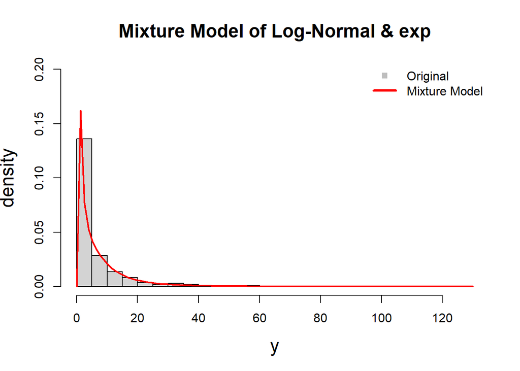

```r
#plotting the histogram of the mixture model
hist(dataex5, breaks=45, main = "Mixture Model of Log-Normal & exp",
     xlab = "y", ylab = "density", ylim = c(0,0.2),
     cex.main = 1.5, cex.lab = 1.5, freq = F)
curve(p*dlnorm(x, mu, sigma)+(1-p)*dexp(x, lambda), add = TRUE, lwd = 2, col = "red")
legend("topright", c("Original", "Mixture Model"), col=c("gray", "red"),
       bty="n",lty = c(NA, 1), pch = c(15, NA),lwd=c(100,3))
```